title: “Projeto MNIST: Classificação de Dígitos com Redes Neurais Densa e Convolucional” author: “David Kallas Pinto” date: “2025-06-15”

### 1. Introdução:

Esse projeto foi elaborado com o objetivo de praticar o desenvolvimento de redes neurais em Machine Learning usando a base de dados MNIST para classificação de dígitos manuscritos usando R. Durante o projeto, foram elaboradas duas redes neurais, a primeira uma Rede Neural Densa (MLP) e posteriormente uma Rede Neural Convolucional (CNN). Durante o desenvolvimento, a ideia foi explorar diferentes hiperparâmetros e complexidades de arquiteturas para as redes neurais a fim de testar e compreender como cada uma delas pode performar e exigir diferentes níveis de processamento computacional. Ao final, foi possível avaliar por meio das métricas (accuracy e loss) a performance de cada modelo e observar onde os erros foram cometidos.

### 2. Configuração e Carregamento dos Dados

```r
# Carrega a biblioteca Keras
library(keras)

# Carrega o conjunto de dados MNIST
mnist <- dataset_mnist()

# Separando os dados em conjuntos de treinamento e teste
x_train <- mnist$train$x
y_train <- mnist$train$y

x_test <- mnist$test$x
y_test_original <- mnist$test$y # Guardamos o y_test original para comparação posterior
```

### 3. Exploração e Visualização dos Dados

```r
str(x_train) # 60.000 imagens, cada uma 28x28 pixels
```

```
##  int [1:60000, 1:28, 1:28] 0 0 0 0 0 0 0 0 0 0 ...
```

```r
str(y_train) # 60.000 rótulos (inteiros de 0 a 9)
```

```
##  int [1:60000(1d)] 5 0 4 1 9 2 1 3 1 4 ...
```

```r
str(x_test) # 10.000 imagens de teste, cada uma 28x28 pixels
```

```
##  int [1:10000, 1:28, 1:28] 0 0 0 0 0 0 0 0 0 0 ...
```

```r
str(y_test_original) # 10.000 rótulos de teste
```

```
##  int [1:10000(1d)] 7 2 1 0 4 1 4 9 5 9 ...
```

Cada pixel da imagem tem um valor inteiro entre 0 e 255, representando a intensidade do cinza. Para uma melhor compreensão visual, vamos plotar algumas amostras aleatórias do conjunto de treinamento.

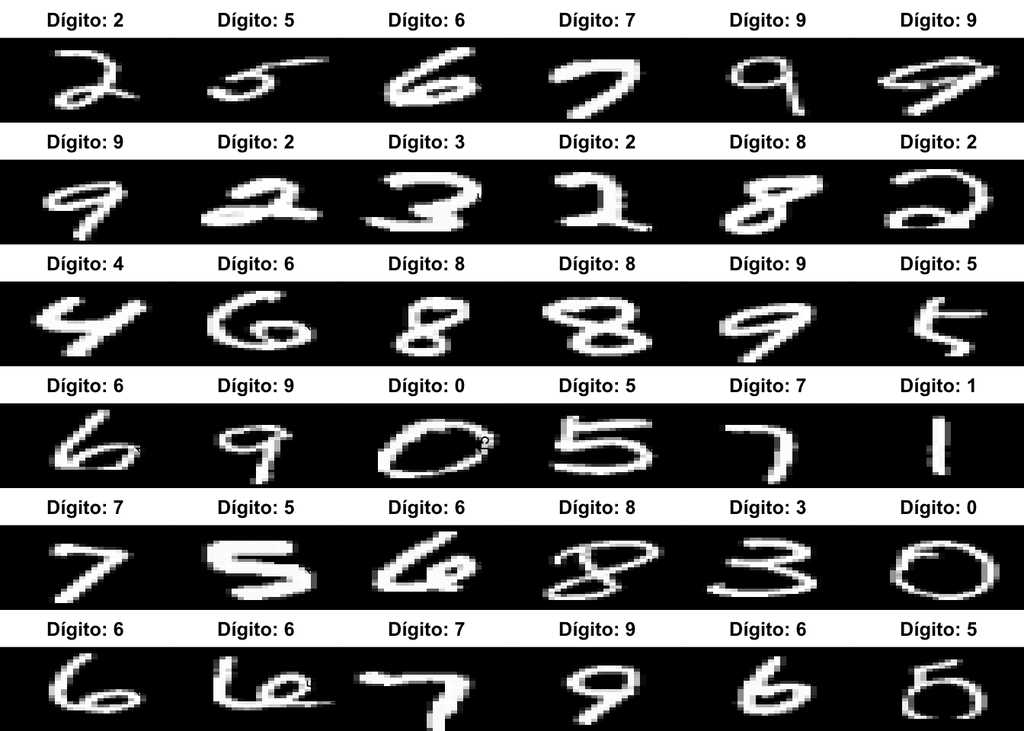

```r
# Configura o layout da plotagem para mostrar 6x6 imagens
par(mfcol = c(6, 6))
# Ajusta as margens para maximizar o espaço das imagens
par(mar = c(0, 0, 2, 0), xaxs = 'i', yaxs = 'i')

# Define uma semente para reprodutibilidade das amostras e seleciona 36 índices aleatórios
set.seed(42)
indices <- sample(nrow(x_train), 36)

# Loop para plotar cada imagem selecionada
for (idx in indices) {
  im <- x_train[idx, , ] # Extrai a imagem
  im <- t(apply(im, 2, rev))  # Transpõe e inverte as linhas
  image(1:28, 1:28, im, col = gray((0:255)/255),
        xaxt = 'n', main = paste("Dígito:", y_train[idx]))  # Plota a imagem
}
```

```r
# Restaura as configurações de plotagem padrão após o loop
par(mfrow=c(1,1))
```

### 4. Pré-processamento dos Dados (Comum/Inicial)

As Redes Neurais esperam dados em um formato específico. Aqui, faremos os pré-processamentos iniciais que serão comuns ou ajustados para ambas as arquiteturas. Os valores dos pixels (0-255) são convertidos para uma escala de 0 a 1.

```r
# Converte os valores dos pixels de inteiros (0-255) para ponto flutuante (0-1)
x_train <- x_train / 255
x_test <- x_test / 255

print(x_train[1, 10, 10])
```

```
## [1] 0.6117647
```

Aqui por exemplo, temos um exemplo de Valor de Pixel Normalizado.

#### One-Hot Encoding dos Rótulos

Os rótulos (dígitos de 0 a 9) são convertidos para o formato one-hot encoding. Cada rótulo se torna um vetor binário de 10 posições, onde apenas a posição correspondente ao dígito é 1 e as outras são 0. Por exemplo, o dígito `3` vira `[0, 0, 0, 1, 0, 0, 0, 0, 0, 0]`.

```r
# Converte os vetores de rótulos inteiros para matrizes de classe binária (one-hot)
y_train <- to_categorical(y_train, 10) # 10 classes (0 a 9)
y_test <- to_categorical(y_test_original, 10) # y_test_original é usado aqui

exemplo_y_original <- y_test_original[1:3]
exemplo_y_onehot <- y_test[1:3, ]
```

### 5. Rede Neural Densa (MLP - Perceptron Multicamadas)

#### 5.1. Pré-processamento Específico para MLP

Para a MLP, as imagens 28x28 precisam ser achatadas em vetores de 784 pixels.

```r
x_train_mlp <- array_reshape(x_train, c(nrow(x_train), 784))
x_test_mlp <- array_reshape(x_test, c(nrow(x_test), 784))
```

Cada linha agora representa uma imagem completa como um vetor único.

#### 5.2. Definição da Arquitetura MLP

Nossa MLP terá múltiplas camadas densas com ativação ReLU e camadas de Dropout para regularização. A camada final usará Softmax para classificação multiclasse.

```r
modelo_mlp <- keras_model_sequential()

modelo_mlp %>%
  layer_dense(units = 256, activation = 'relu', input_shape = c(784)) %>% # Primeira camada, define a forma de entrada
  layer_dropout(rate = 0.4) %>% # Dropout para regularização (40% dos neurônios "desligados")
  layer_dense(units = 128, activation = 'relu') %>%
  layer_dropout(rate = 0.2) %>%
  layer_dense(units = 100, activation = 'relu') %>%
  layer_dropout(rate = 0.4) %>%
  layer_dense(units = 80, activation = 'relu') %>%
  layer_dropout(rate = 0.3) %>%
  layer_dense(units = 50, activation = 'relu') %>%
  layer_dropout(rate = 0.1) %>%
  layer_dense(units = 30, activation = 'relu') %>%
  layer_dropout(rate = 0.3) %>%
  layer_dense(units = 10, activation = 'softmax') # Camada de saída: 10 neurônios para as 10 classes, ativação softmax para probabilidades

summary(modelo_mlp)
```

```
## Model: "sequential"
## ________________________________________________________________________________
##  Layer (type)                       Output Shape                    Param #
## ================================================================================
##  dense_6 (Dense)                    (None, 256)                     200960
##  dropout_5 (Dropout)                (None, 256)                     0
##  dense_5 (Dense)                    (None, 128)                     32896
##  dropout_4 (Dropout)                (None, 128)                     0
##  dense_4 (Dense)                    (None, 100)                     12900
##  dropout_3 (Dropout)                (None, 100)                     0
##  dense_3 (Dense)                    (None, 80)                      8080
##  dropout_2 (Dropout)                (None, 80)                      0
##  dense_2 (Dense)                    (None, 50)                      4050
##  dropout_1 (Dropout)                (None, 50)                      0
##  dense_1 (Dense)                    (None, 30)                      1530
##  dropout (Dropout)                  (None, 30)                      0
##  dense (Dense)                      (None, 10)                      310
## ================================================================================
## Total params: 260726 (1018.46 KB)
## Trainable params: 260726 (1018.46 KB)
## Non-trainable params: 0 (0.00 Byte)
## ________________________________________________________________________________
```

#### 5.3. Compilação da MLP

Antes de treinar, o modelo precisa ser compilado, definindo a função de perda, o otimizador e as métricas.  
A compilação prepara o modelo para o treinamento, definindo como ele aprenderá e será avaliado.

```r
# Compila o modelo com as configurações de treinamento
modelo_mlp <- compile(modelo_mlp,
                      loss = 'categorical_crossentropy', # Função de perda para problemas de classificação multiclasse (com one-hot encoding)
                      optimizer = "adam",                 # Otimizador Adam
                      metrics = c("accuracy")             # Métrica para avaliar o desempenho durante o treinamento
)
```

#### 5.4. Treinamento da MLP com Early Stopping

Treinaremos o modelo usando o conjunto de treinamento. O `Early Stopping` será usado para monitorar a performance no conjunto de validação e interromper o treinamento se a perda de validação parar de melhorar, evitando assim o overfitting.

```r
# Define o callback de Early Stopping
# Monitora a val_loss (perda no conjunto de validação)
# patience = 10 significa que o treinamento será interrompido se a val_loss não melhorar por 10 épocas consecutivas
# restore_best_weights = TRUE garante que o modelo mantenha os pesos da melhor época de validação
callbacks_mlp <- list(
  callback_early_stopping(
    monitor = "val_loss",
    min_delta = 0,
    patience = 10,
    verbose = 1,
    mode = "auto",
    restore_best_weights = TRUE
  )
)

history_mlp <- modelo_mlp %>% fit(
  x_train_mlp, y_train,        # Dados de treinamento e rótulos
  epochs = 50,                 # Número máximo de épocas. Early Stopping pode parar antes.
  batch_size = 128,            # Número de amostras por atualização de gradiente
  validation_split = 0.2,      # 20% dos dados de treino serão usados para validação
  callbacks = callbacks_mlp    # Aplica o callback de Early Stopping
)
```

```
## 375/375 - 1s - loss: 1.0470 - accuracy: 0.6366 - val_loss: 0.2456 - val_accuracy: 0.9327 - 1s/epoch - 4ms/step
## 375/375 - 1s - loss: 0.3923 - accuracy: 0.9025 - val_loss: 0.1701 - val_accuracy: 0.9563 - 1s/epoch - 3ms/step
## 375/375 - 1s - loss: 0.2969 - accuracy: 0.9295 - val_loss: 0.1496 - val_accuracy: 0.9615 - 972ms/epoch - 3ms/step
## 375/375 - 1s - loss: 0.2460 - accuracy: 0.9438 - val_loss: 0.1281 - val_accuracy: 0.9672 - 993ms/epoch - 3ms/step
## 375/375 - 1s - loss: 0.2203 - accuracy: 0.9489 - val_loss: 0.1246 - val_accuracy: 0.9701 - 968ms/epoch - 3ms/step
## 375/375 - 1s - loss: 0.2000 - accuracy: 0.9547 - val_loss: 0.1244 - val_accuracy: 0.9707 - 968ms/epoch - 3ms/step
## 375/375 - 1s - loss: 0.1842 - accuracy: 0.9577 - val_loss: 0.1198 - val_accuracy: 0.9688 - 958ms/epoch - 3ms/step
## 375/375 - 1s - loss: 0.1749 - accuracy: 0.9590 - val_loss: 0.1174 - val_accuracy: 0.9728 - 965ms/epoch - 3ms/step
## 375/375 - 1s - loss: 0.1602 - accuracy: 0.9634 - val_loss: 0.1207 - val_accuracy: 0.9728 - 977ms/epoch - 3ms/step
## 375/375 - 1s - loss: 0.1564 - accuracy: 0.9644 - val_loss: 0.1169 - val_accuracy: 0.9732 - 967ms/epoch - 3ms/step
## 375/375 - 1s - loss: 0.1439 - accuracy: 0.9669 - val_loss: 0.1185 - val_accuracy: 0.9731 - 972ms/epoch - 3ms/step
## 375/375 - 1s - loss: 0.1379 - accuracy: 0.9679 - val_loss: 0.1219 - val_accuracy: 0.9742 - 964ms/epoch - 3ms/step
## 375/375 - 1s - loss: 0.1279 - accuracy: 0.9700 - val_loss: 0.1239 - val_accuracy: 0.9738 - 973ms/epoch - 3ms/step
## 375/375 - 1s - loss: 0.1265 - accuracy: 0.9705 - val_loss: 0.1191 - val_accuracy: 0.9752 - 971ms/epoch - 3ms/step
## 375/375 - 1s - loss: 0.1261 - accuracy: 0.9703 - val_loss: 0.1148 - val_accuracy: 0.9747 - 1s/epoch - 3ms/step
## 375/375 - 1s - loss: 0.1186 - accuracy: 0.9723 - val_loss: 0.1149 - val_accuracy: 0.9754 - 955ms/epoch - 3ms/step
## 375/375 - 1s - loss: 0.1137 - accuracy: 0.9732 - val_loss: 0.1084 - val_accuracy: 0.9775 - 959ms/epoch - 3ms/step
## 375/375 - 1s - loss: 0.1104 - accuracy: 0.9745 - val_loss: 0.1004 - val_accuracy: 0.9782 - 992ms/epoch - 3ms/step
## 375/375 - 1s - loss: 0.1058 - accuracy: 0.9751 - val_loss: 0.1019 - val_accuracy: 0.9779 - 959ms/epoch - 3ms/step
## 375/375 - 1s - loss: 0.1060 - accuracy: 0.9755 - val_loss: 0.1087 - val_accuracy: 0.9789 - 949ms/epoch - 3ms/step
## 375/375 - 1s - loss: 0.1061 - accuracy: 0.9760 - val_loss: 0.1075 - val_accuracy: 0.9764 - 982ms/epoch - 3ms/step
## 375/375 - 1s - loss: 0.0991 - accuracy: 0.9766 - val_loss: 0.1084 - val_accuracy: 0.9768 - 955ms/epoch - 3ms/step
## 375/375 - 1s - loss: 0.0959 - accuracy: 0.9775 - val_loss: 0.1130 - val_accuracy: 0.9776 - 959ms/epoch - 3ms/step
## 375/375 - 1s - loss: 0.0941 - accuracy: 0.9774 - val_loss: 0.1029 - val_accuracy: 0.9779 - 954ms/epoch - 3ms/step
## 375/375 - 1s - loss: 0.0871 - accuracy: 0.9784 - val_loss: 0.1060 - val_accuracy: 0.9774 - 975ms/epoch - 3ms/step
## 375/375 - 1s - loss: 0.0939 - accuracy: 0.9783 - val_loss: 0.1082 - val_accuracy: 0.9769 - 967ms/epoch - 3ms/step
## 375/375 - 1s - loss: 0.0913 - accuracy: 0.9779 - val_loss: 0.1071 - val_accuracy: 0.9781 - 963ms/epoch - 3ms/step
## Restoring model weights from the end of the best epoch: 18.
## 375/375 - 1s - loss: 0.0846 - accuracy: 0.9798 - val_loss: 0.1079 - val_accuracy: 0.9781 - 964ms/epoch - 3ms/step
## Epoch 28: early stopping
```

#### 5.5. Avaliação e Interpretação dos Resultados da MLP

Vamos analisar o histórico de treinamento para entender como o modelo aprendeu e, em seguida, avaliá-lo no conjunto de teste para uma estimativa final de seu desempenho.

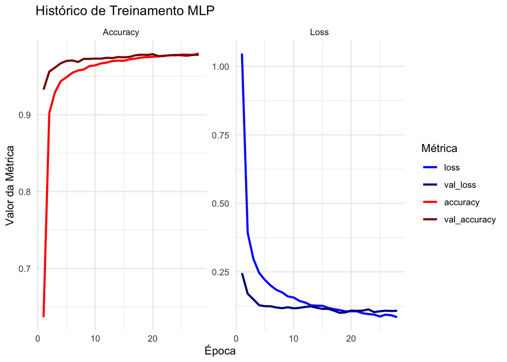

```r
metrics_mlp <- as.data.frame(history_mlp$metrics)
metrics_mlp$epoch <- 1:nrow(metrics_mlp)

history_melt_mlp <- melt(metrics_mlp, id.vars = "epoch",
                         measure.vars = c("loss", "val_loss", "accuracy", "val_accuracy"))

# Plota a perda e a acurácia ao longo das épocas
ggplot(history_melt_mlp, aes(x = epoch, y = value, color = variable)) +
  geom_line(size = 1) +
  facet_wrap(~ ifelse(grepl("loss", variable), "Loss", "Accuracy"), scales = "free_y") +
  labs(title = "Histórico de Treinamento MLP",
       x = "Época",
       y = "Valor da Métrica",
       color = "Métrica") +
  theme_minimal() +
  scale_color_manual(values = c("loss" = "blue", "val_loss" = "darkblue",
                                "accuracy" = "red", "val_accuracy" = "darkred"))
```

A análise do gráfico acima nos mostra a evolução da perda e acurácia. Agora, vamos avaliar o modelo no conjunto de teste.

```r
# Avalia o modelo no conjunto de teste (dados não vistos)
eval_mlp <- modelo_mlp %>% evaluate(x_test_mlp, y_test)
```

```
## 313/313 - 0s - loss: 0.1008 - accuracy: 0.9780 - 158ms/epoch - 504us/step
```

```r
print(eval_mlp) # Exibe a perda e acurácia no teste
```

```
##      loss  accuracy
## 0.1008048 0.9780000
```

A acurácia no conjunto de teste é a estimativa mais imparcial do desempenho do modelo em dados novos.

```r
# Realiza predições no conjunto de teste
# predict() retorna probabilidades, k_argmax() pega a classe com maior probabilidade
pred_mlp <- modelo_mlp %>% predict(x_test_mlp) %>% k_argmax() %>% k_get_value()
```

```
## 313/313 - 0s - 202ms/epoch - 646us/step
```

```r
# Calcula a acurácia manualmente para confirmação
acuracia_manual_mlp <- mean(y_test_original == as.numeric(pred_mlp))
print(acuracia_manual_mlp)
```

```
## [1] 0.978
```

Acurácia Manual da MLP no Conjunto de Teste

```r
# Cria um dataframe para armazenar o resultado da MLP
resultados_comparacao <- data.frame(Modelo = "Rede Densa (MLP)",
                                    Perda_Teste = eval_mlp["loss"],
                                    Acuracia_Teste = eval_mlp["accuracy"],
                                    stringsAsFactors = FALSE)
```

#### Análise da MLP:

A Rede Densa alcançou uma acurácia de teste de aproximadamente 97.8%. Agora, vamos aplicar um modelo de Rede Neural Convolucional, a qual didaticamente é vista como uma rede projetada para lidar melhor com a estrutura espacial de imagens, pois elas preservam a estrutura espacial dos dados de imagem e aprendem características hierárquicas (bordas, formas, etc.) de forma mais eficaz.

### 6. Rede Neural Convolucional (CNN)

#### 6.1. Pré-processamento Específico para CNN

Para CNNs, as imagens precisam ser formatadas como um tensor 4D: `(número_de_amostras, largura, altura, canais)`. Para as imagens em tons de cinza do MNIST, o número de canais é 1.

```r
# Reajusta os arrays 3D para arrays 4D (número_de_imagens, largura, altura, canais).
# Para MNIST (escala de cinza), o número de canais é 1.
x_train_cnn <- array_reshape(x_train, c(nrow(x_train), 28, 28, 1))
x_test_cnn <- array_reshape(x_test, c(nrow(x_test), 28, 28, 1))

str(x_train_cnn)
```

```
##  num [1:60000, 1:28, 1:28, 1] 0 0 0 0 0 0 0 0 0 0 ...
```

A dimensão extra ‘1’ indica um único canal de cor (tons de cinza).

#### 6.2. Definição da Arquitetura CNN

Nossa CNN incluirá camadas convolucionais (`layer_conv_2d`) para extração de características, camadas de pooling (`layer_max_pooling_2d`) para redução de dimensionalidade e camadas densas para classificação.

```r
# Inicia um novo modelo sequencial para a CNN
modelo_cnn <- keras_model_sequential()

modelo_cnn %>%

  layer_conv_2d(filters = 32, kernel_size = c(3, 3), activation = 'relu', input_shape = c(28, 28, 1)) %>%
  layer_max_pooling_2d(pool_size = c(2, 2)) %>%
  layer_conv_2d(filters = 64, kernel_size = c(3, 3), activation = 'relu') %>%
  layer_max_pooling_2d(pool_size = c(2, 2)) %>%
  layer_flatten() %>%
  layer_dense(units = 128, activation = 'relu') %>%
  layer_dropout(rate = 0.5) %>%
  layer_dense(units = 10, activation = 'softmax')

summary(modelo_cnn)
```

```
## Model: "sequential_1"
## ________________________________________________________________________________
##  Layer (type)                       Output Shape                    Param #
## ================================================================================
##  conv2d_1 (Conv2D)                  (None, 26, 26, 32)              320
##  max_pooling2d_1 (MaxPooling2D)     (None, 13, 13, 32)              0
##  conv2d (Conv2D)                    (None, 11, 11, 64)              18496
##  max_pooling2d (MaxPooling2D)       (None, 5, 5, 64)                0
##  flatten (Flatten)                  (None, 1600)                    0
##  dense_8 (Dense)                    (None, 128)                     204928
##  dropout_6 (Dropout)                (None, 128)                     0
##  dense_7 (Dense)                    (None, 10)                      1290
## ================================================================================
## Total params: 225034 (879.04 KB)
## Trainable params: 225034 (879.04 KB)
## Non-trainable params: 0 (0.00 Byte)
## ________________________________________________________________________________
```

#### 6.3. Compilação da CNN

A compilação da CNN segue o mesmo princípio da MLP.

```r
# Compila o modelo com as mesmas configurações da MLP para comparação justa
modelo_cnn <- compile(modelo_cnn,
                      loss = 'categorical_crossentropy',
                      optimizer = "adam",
                      metrics = c("accuracy")
)
```

A função de perda e o otimizador são os mesmos, permitindo uma comparação direta da performance das arquiteturas.

#### 6.4. Treinamento da CNN com Early Stopping

Treinaremos a CNN. O `Early Stopping` será novamente importante para encontrar o ponto ótimo de generalização e evitar o overfitting.

```r
# Define o callback de Early Stopping para a CNN (mesmos parâmetros)
callbacks_cnn <- list(
  callback_early_stopping(
    monitor = "val_loss",
    min_delta = 0,
    patience = 10,
    verbose = 1,
    mode = "auto",
    restore_best_weights = TRUE
  )
)

history_cnn <- modelo_cnn %>% fit(
  x_train_cnn, y_train,
  epochs = 50, # Número máximo de épocas. Early Stopping pode parar antes.
  batch_size = 128,
  validation_split = 0.2,
  callbacks = callbacks_cnn
)
```

```
## 375/375 - 7s - loss: 0.3350 - accuracy: 0.8974 - val_loss: 0.0772 - val_accuracy: 0.9777 - 7s/epoch - 19ms/step
## 375/375 - 7s - loss: 0.1109 - accuracy: 0.9669 - val_loss: 0.0553 - val_accuracy: 0.9841 - 7s/epoch - 18ms/step
## 375/375 - 7s - loss: 0.0799 - accuracy: 0.9762 - val_loss: 0.0496 - val_accuracy: 0.9867 - 7s/epoch - 18ms/step
## 375/375 - 7s - loss: 0.0657 - accuracy: 0.9796 - val_loss: 0.0417 - val_accuracy: 0.9889 - 7s/epoch - 18ms/step
## 375/375 - 7s - loss: 0.0569 - accuracy: 0.9831 - val_loss: 0.0431 - val_accuracy: 0.9887 - 7s/epoch - 18ms/step
## 375/375 - 7s - loss: 0.0498 - accuracy: 0.9846 - val_loss: 0.0413 - val_accuracy: 0.9886 - 7s/epoch - 18ms/step
## 375/375 - 7s - loss: 0.0434 - accuracy: 0.9868 - val_loss: 0.0367 - val_accuracy: 0.9899 - 7s/epoch - 18ms/step
## 375/375 - 7s - loss: 0.0393 - accuracy: 0.9882 - val_loss: 0.0364 - val_accuracy: 0.9905 - 7s/epoch - 18ms/step
## 375/375 - 7s - loss: 0.0359 - accuracy: 0.9886 - val_loss: 0.0356 - val_accuracy: 0.9903 - 7s/epoch - 18ms/step
## 375/375 - 7s - loss: 0.0333 - accuracy: 0.9897 - val_loss: 0.0333 - val_accuracy: 0.9909 - 7s/epoch - 19ms/step
## 375/375 - 7s - loss: 0.0278 - accuracy: 0.9910 - val_loss: 0.0353 - val_accuracy: 0.9908 - 7s/epoch - 19ms/step
## 375/375 - 7s - loss: 0.0273 - accuracy: 0.9912 - val_loss: 0.0312 - val_accuracy: 0.9918 - 7s/epoch - 20ms/step
## 375/375 - 7s - loss: 0.0240 - accuracy: 0.9920 - val_loss: 0.0332 - val_accuracy: 0.9921 - 7s/epoch - 20ms/step
## 375/375 - 7s - loss: 0.0220 - accuracy: 0.9927 - val_loss: 0.0337 - val_accuracy: 0.9918 - 7s/epoch - 19ms/step
## 375/375 - 7s - loss: 0.0203 - accuracy: 0.9931 - val_loss: 0.0365 - val_accuracy: 0.9915 - 7s/epoch - 19ms/step
## 375/375 - 7s - loss: 0.0184 - accuracy: 0.9940 - val_loss: 0.0389 - val_accuracy: 0.9902 - 7s/epoch - 19ms/step
## 375/375 - 7s - loss: 0.0184 - accuracy: 0.9941 - val_loss: 0.0359 - val_accuracy: 0.9913 - 7s/epoch - 20ms/step
## 375/375 - 7s - loss: 0.0163 - accuracy: 0.9942 - val_loss: 0.0401 - val_accuracy: 0.9912 - 7s/epoch - 20ms/step
## 375/375 - 8s - loss: 0.0157 - accuracy: 0.9948 - val_loss: 0.0398 - val_accuracy: 0.9918 - 8s/epoch - 20ms/step
## 375/375 - 8s - loss: 0.0158 - accuracy: 0.9950 - val_loss: 0.0389 - val_accuracy: 0.9918 - 8s/epoch - 21ms/step
## 375/375 - 7s - loss: 0.0139 - accuracy: 0.9952 - val_loss: 0.0389 - val_accuracy: 0.9920 - 7s/epoch - 20ms/step
## Restoring model weights from the end of the best epoch: 12.
## 375/375 - 7s - loss: 0.0132 - accuracy: 0.9951 - val_loss: 0.0393 - val_accuracy: 0.9917 - 7s/epoch - 20ms/step
## Epoch 22: early stopping
```

#### 6.5. Avaliação e Interpretação dos Resultados da CNN

Vamos plotar o histórico de treinamento da CNN e avaliá-la no conjunto de teste.

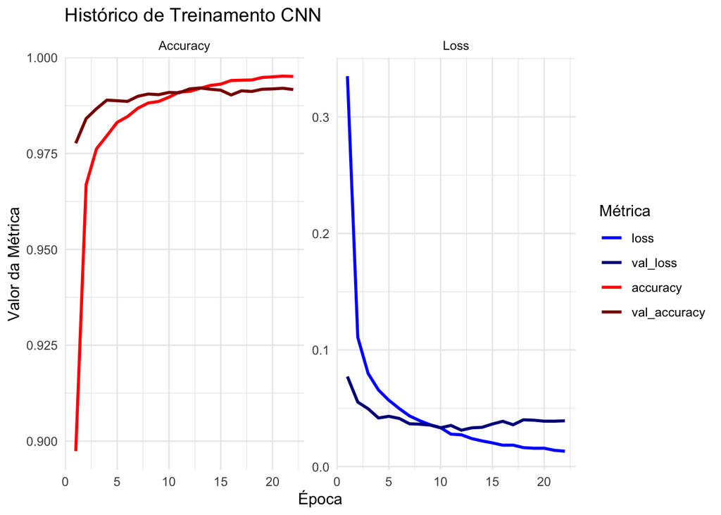

```r
# Acessa as métricas diretamente do objeto history_cnn
metrics_cnn <- as.data.frame(history_cnn$metrics)
metrics_cnn$epoch <- 1:nrow(metrics_cnn)

history_melt_cnn <- melt(metrics_cnn, id.vars = "epoch",
                         measure.vars = c("loss", "val_loss", "accuracy", "val_accuracy"))

ggplot(history_melt_cnn, aes(x = epoch, y = value, color = variable)) +
  geom_line(size = 1) +
  facet_wrap(~ ifelse(grepl("loss", variable), "Loss", "Accuracy"), scales = "free_y") +
  labs(title = "Histórico de Treinamento CNN",
       x = "Época",
       y = "Valor da Métrica",
       color = "Métrica") +
  theme_minimal() +
  scale_color_manual(values = c("loss" = "blue", "val_loss" = "darkblue",
                                "accuracy" = "red", "val_accuracy" = "darkred"))
```

Vamos avaliar a CNN no conjunto de teste.

```r
# Avalia o modelo CNN no conjunto de teste
eval_cnn <- modelo_cnn %>% evaluate(x_test_cnn, y_test)
```

```
## 313/313 - 1s - loss: 0.0233 - accuracy: 0.9921 - 638ms/epoch - 2ms/step
```

```r
print(eval_cnn)
```

```
##       loss   accuracy
## 0.02334519 0.99210000
```

Espera-se uma acurácia significativamente maior para a CNN.

```r
# Realiza predições no conjunto de teste
pred_cnn <- modelo_cnn %>% predict(x_test_cnn) %>% k_argmax() %>% k_get_value()
```

```
## 313/313 - 1s - 592ms/epoch - 2ms/step
```

```r
# Calcula a acurácia manualmente
acuracia_manual_cnn <- mean(y_test_original == as.numeric(pred_cnn))
print(acuracia_manual_cnn)
```

```
## [1] 0.9921
```

```r
# Adiciona o resultado da CNN ao dataframe de comparação
resultados_comparacao[nrow(resultados_comparacao)+1, ] <- c("Rede Convolucional (CNN)",
                                                             eval_cnn["loss"],
                                                             eval_cnn["accuracy"])
```

### 7. Comparação e Conclusão Final

Aqui, vamos comparar diretamente os resultados de ambas as arquiteturas e concluir sobre a eficácia de cada uma para o problema MNIST.

#### 7.1 Tabela de performance

```r
temp_resultados_comparacao <- resultados_comparacao

temp_resultados_comparacao$Perda_Teste <- as.numeric(temp_resultados_comparacao$Perda_Teste)
temp_resultados_comparacao$Acuracia_Teste <- as.numeric(temp_resultados_comparacao$Acuracia_Teste)

knitr::kable(temp_resultados_comparacao,
             caption = "Comparação da Performance dos Modelos (Conjunto de Teste)",
             col.names = c("Modelo", "Perda no Teste", "Acurácia no Teste"),
             digits = 3
)
```

Comparação da Performance dos Modelos (Conjunto de Teste)

|  | Modelo | Perda no Teste | Acurácia no Teste |
| --- | --- | --- | --- |
| loss | Rede Densa (MLP) | 0.101 | 0.978 |
| 2 | Rede Convolucional (CNN) | 0.023 | 0.992 |

#### 7.2 Visualização dos erros:

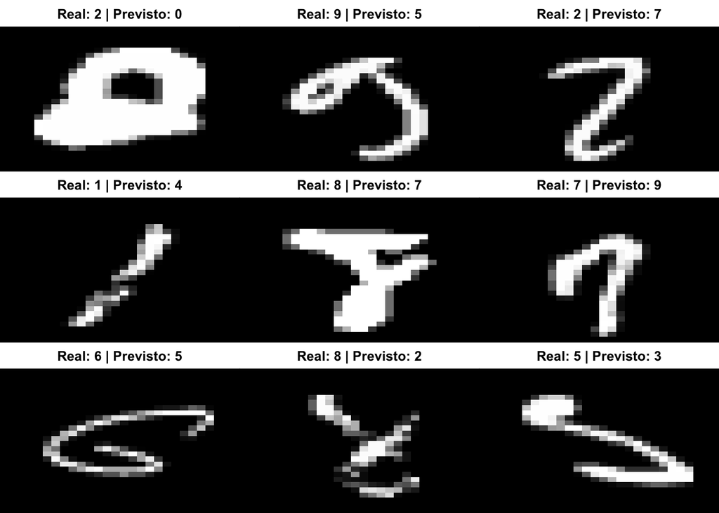

```r
erros_indices <- which(y_test_original != as.numeric(pred_cnn))

# Plota até 9 erros de exemplo
num_erros_plot <- min(length(erros_indices), 9)

# Configura o layout da plotagem para mostrar as imagens de erro
par(mfcol = c(3, 3))
par(mar = c(0, 0, 2, 0), xaxs = 'i', yaxs = 'i')

# Seleciona aleatoriamente os índices dos erros para plotar
erros_selecionados <- sample(erros_indices, num_erros_plot)

# Loop para plotar cada imagem de erro
for (idx in erros_selecionados) {
  im <- mnist$test$x[idx, , ]
  im <- t(apply(im, 2, rev))
  image(1:28, 1:28, im, col = gray((0:255)/255),
        xaxt = 'n', main = paste("Real:", y_test_original[idx], "| Previsto:", pred_cnn[idx]))
}
```

```r
# Restaura as configurações de plotagem padrão após o loop
par(mfrow=c(1,1))
```

#### 7.3 Conclusão

Podemos concluir que:

Ficou muito claro o porquê as CNNs são a escolha preferencial para problemas de visão computacional. Uma vez que, apresentaram performance superior em comparação com uma MLP. A CNN não só entregou uma acurácia maior no conjunto de teste, como também mostrou uma convergência mais rápida e estável durante o treinamento.

A implementação do Early Stopping foi importante para evitar o overfitting e reduzir tempo de processamento. O modelo estava no seu melhor equilíbrio entre aprender e generalizar, evitando que continuasse a treinar e talvez sobreajustar aos dados de treinamento. Sem ele, poderíamos ter pego um modelo ligeiramente menos otimizado.

A visualização dos erros da CNN foi bastante interessante para trazer um entendimento mais concreto da base e de como existem dígitos “confusos” que podem levar a inconsistências. Mesmo com alta acurácia, é sempre interessante ver onde o modelo ainda “tropeça”.

As redes neurais, em sua estrutura de ‘black box’ possuem hiperparâmetros que devem ser explorados e testados para que somente assim, a melhor arquitetura seja alcançada.